# Predict Popularity

Mary Solomon

2/11/2021

global functions (convert key to dummy)

```r
key.dummy <- function(x){
  x <- x %>% mutate(key1 = ifelse(x$key == 1, 1, 0),
              key2 = ifelse(x$key == 2, 1, 0),
              key3 = ifelse(x$key == 3, 1, 0),
              key4 = ifelse(x$key == 4, 1, 0),
              key5 = ifelse(x$key == 5, 1, 0),
              key6 = ifelse(x$key == 6, 1, 0),
              key7 = ifelse(x$key == 7, 1, 0),
              key8 = ifelse(x$key == 8, 1, 0),
              key9 = ifelse(x$key == 9, 1, 0),
              key10 = ifelse(x$key == 10, 1, 0),
              key11 = ifelse(x$key == 11, 1, 0)) %>% select(-key)

  x
}

#train/valid/test function from data mining class:
partition.3 <- function(data, prop.train, prop.val){
  # select a random sample of size = prop.train % of total records
  selected1 <- sample(1:nrow(data), round(nrow(data)*prop.train), replace = FALSE)
  # create training data which has prop.train % of total records
  data.train <- data[selected1,]
  # select a random sample of size = prop.val % of the total records
  rest <- setdiff(1:nrow(data), selected1)
  selected2 <- sample(rest, round(nrow(data)*prop.val), replace = FALSE)
  # create validation data which has prop.val % of total records
  data.val <- data[selected2,]
  # create testing data with the remaining records
  data.test <- data[setdiff(rest, selected2),]
  return(list(data.train=data.train, data.test=data.test, data.val=data.val))
}

#creates plot for optimal cut off value
opt.cut.func <- function(model, data){
  # create a vector for cutoff values
  cutoff <- seq(0, 1, 0.01)

  # create three empty vectors of same length
  sensitivity.vec <- rep(NA, length(cutoff))
  specificity.vec <- rep(NA, length(cutoff))
  ssdiff.vec <- rep(NA, length(cutoff))
  kappa.vec <- rep(NA, length(cutoff))

# For loop.
  for(i in 1:length(cutoff)){
    pred.prob.val <- predict(model, newdata = data, type = "response")
    pred.y.val <- as.factor(ifelse(pred.prob.val > cutoff[i], 1, 0))
    # warning messages galore because the probability of a value actually being popular is SO LOW
    c <- confusionMatrix(pred.y.val, data$popular,
                        positive = "1")
    sensitivity.vec[i] <- c$byClass["Sensitivity"]
    specificity.vec[i] <- c$byClass["Specificity"]
    ssdiff.vec[i] <- abs(sensitivity.vec[i] - specificity.vec[i])
    kappa.vec[i] <- c$overall["Kappa"]
  }
  return(list(cutoff = cutoff, sensitivity.vec = sensitivity.vec, specificity.vec = specificity.vec, ssdiff.vec = ssdiff.vec, kappa.vec = kappa.vec))
}

opt.cut.plot <- function(opt.out){
  plot(opt.out$cutoff, opt.out$sensitivity.vec,xlab = "cutoff", type = "l", col = "blue")
  lines(opt.out$cutoff, opt.out$specificity.vec, type = "l", col = "green")
  lines(opt.out$cutoff, opt.out$kappa.vec, type = "l", col = "red")
  legend( x="right", legend=c("Sensitivity","Specificity", "Kappa"),
        col=c("blue","green","red"), lty = 1, lwd=1)

}
```

data :D

```r
data <- fread("kpopdata.csv")
data <- mutate(data, ArtistType = as.factor(ArtistType),
               ArtistGender = as.factor(ArtistGender),
               ArtistGen = factor(ArtistGen),
               release_date = as.POSIXct(release_date, format = "%m/%d/%y"),
               key = factor(key, levels = 0:11),
               mode = as.factor(mode),
               time_signature = factor(time_signature, levels = c(1,3,4,5)),
               popular = factor(ifelse(popularity >=50, 1, 0)))
```

understanding popularity

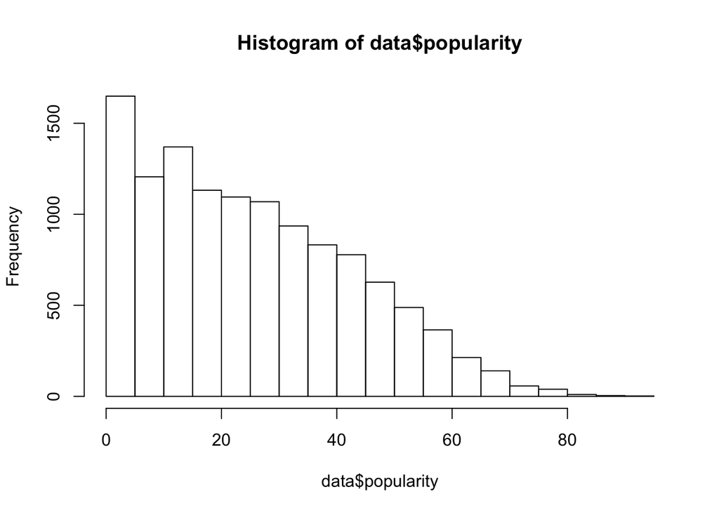

```r
hist(data$popularity)
```

```r
summary(data$popularity)
```

```
##    Min. 1st Qu.  Median    Mean 3rd Qu.    Max.
##    0.00   11.00   23.00   25.88   39.00   94.00
```

heavily skewed right.

The square root transformation makes it more normal. This will help to meet the multiple linear regression assumptions.

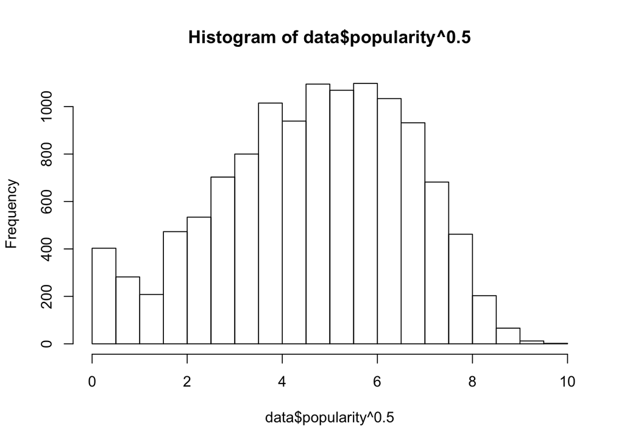

```r
hist(data$popularity^0.5)
```

```r
table(data$popular)/nrow(data)
```

```
##
##         0         1
## 0.8812021 0.1187979
```

if classifying a song as popular when it's score is greater than 50, only ~12% of the data is considered a popular song.

```
kpop <- dplyr::select(data, popularity, duration, acousticness, danceability, energy, instrumentalness, key, loudness, mode, speechiness, time_signature, tempo, valence)
```

General Assumptions: continuous response: popularity score ranging from 0 - 100. mix of categorical and continuous response. the distribution of the variables are not normal, we will check for normality of error terms where appropriate.

Goal: create model for predicting popularity scores

# Multiple Linear Model?

select just audio features

```r
kpop <- select(data, popularity, duration, acousticness, danceability, energy, instrumentalness, key, loudness, mode, speechiness, tempo, valence)
kpop0 <- kpop %>% filter(mode == 0)%>% select(-mode)
kpop1 <- kpop %>% filter(mode == 1) %>% select(-mode)

### Kpop mode 0 train and test
smpl.size0 <- floor(0.75*nrow(kpop0))
set.seed(123)
smpl0 <- sample(nrow(kpop0), smpl.size0, replace = FALSE)
train0 <- kpop0[smpl0,]
test0 <- kpop0[-smpl0,]

### Kpop mode 1 train and test
smpl.size1 <- floor(0.75*nrow(kpop1))
set.seed(123)
smpl1 <- sample(nrow(kpop1), smpl.size1, replace = FALSE)
train1 <- kpop1[smpl1,]
test1 <- kpop1[-smpl1,]
```

fit a multiple linear regression model

```r
ml0 <- lm(popularity ~. , data = train0)
summary(ml0)
```

```
##
## Call:
## lm(formula = popularity ~ ., data = train0)
##
## Residuals:
##     Min      1Q  Median      3Q     Max
## -38.283 -13.161  -1.606  11.489  64.381
##
## Coefficients:
##                   Estimate Std. Error t value Pr(>|t|)
## (Intercept)       98.43022    4.99248  19.716  < 2e-16 ***
## duration          -5.41104    0.55905  -9.679  < 2e-16 ***
## acousticness      -3.81930    2.05303  -1.860 0.062924 .
## danceability      -2.19279    3.28543  -0.667 0.504544
## energy           -33.97108    3.33505 -10.186  < 2e-16 ***
## instrumentalness -15.67494    4.37625  -3.582 0.000346 ***
## key1              -1.20599    1.49947  -0.804 0.421291
## key2              -2.72991    1.85598  -1.471 0.141416
## key3               3.04084    2.07581   1.465 0.143040
## key4              -4.34609    1.46983  -2.957 0.003129 **
## key5              -0.56490    1.42695  -0.396 0.692217
## key6               1.34681    1.48984   0.904 0.366062
## key7               0.04123    1.63277   0.025 0.979856
## key8              -1.57381    1.76361  -0.892 0.372251
## key9              -0.94547    1.51224  -0.625 0.531872
## key10             -1.75720    1.55635  -1.129 0.258955
## key11             -2.41842    1.38950  -1.740 0.081861 .
## loudness           3.55623    0.20271  17.543  < 2e-16 ***
## speechiness       23.77941    4.74755   5.009 5.75e-07 ***
## tempo             -0.00429    0.01255  -0.342 0.732398
## valence          -11.88489    1.78863  -6.645 3.51e-11 ***
## ---
## Signif. codes:  0 '***' 0.001 '**' 0.01 '*' 0.05 '.' 0.1 ' ' 1
##
## Residual standard error: 17.34 on 3483 degrees of freedom
## Multiple R-squared:  0.143,  Adjusted R-squared:  0.138
## F-statistic: 29.05 on 20 and 3483 DF,  p-value: < 2.2e-16
```

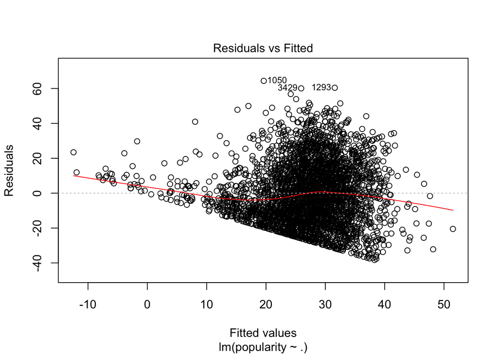

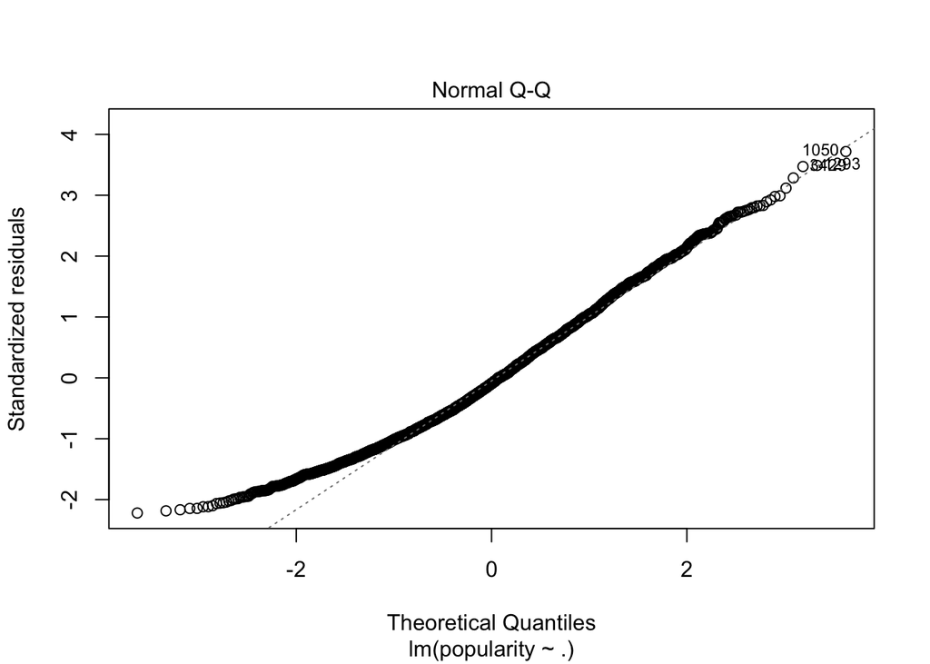

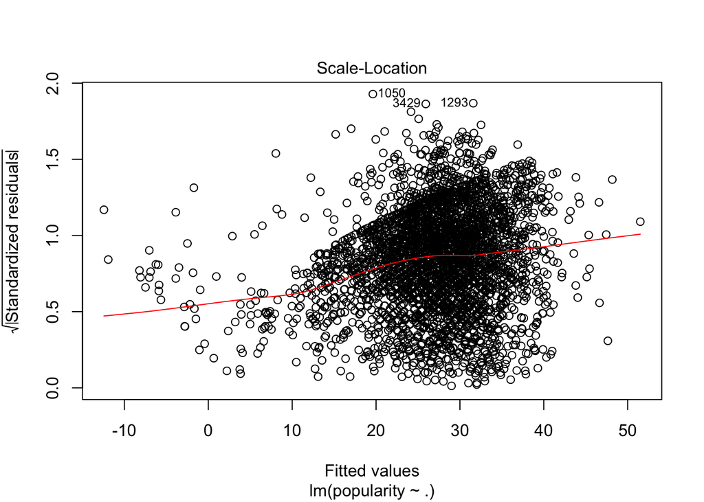

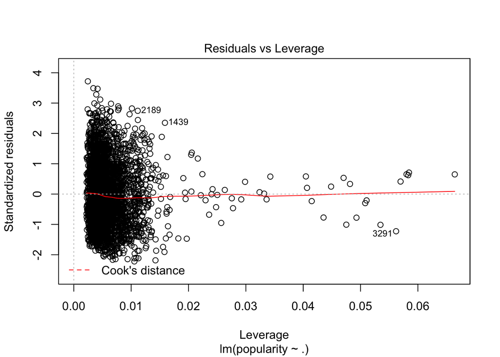

```r
plot(ml0)
```

no or little multicollinearity

no autocorrelation

no homoscedasticity.

Try again with tranformation to make popularity normal:(to the squareroot)

```r
ml0.sqrt <- lm(popularity ~. , data = train0 %>% mutate(popularity = popularity^0.5))
summary(ml0.sqrt)
```

```
##
## Call:
## lm(formula = popularity ~ ., data = train0 %>% mutate(popularity = popularity^0.5))
##
## Residuals:
##     Min      1Q  Median      3Q     Max
## -5.9651 -1.2163  0.1704  1.3715  5.2110
##
## Coefficients:
##                    Estimate Std. Error t value Pr(>|t|)
## (Intercept)      12.8026945  0.5397564  23.719  < 2e-16 ***
## duration         -0.5857021  0.0604408  -9.691  < 2e-16 ***
## acousticness     -0.1418036  0.2219612  -0.639 0.522952
## danceability     -0.1381154  0.3552010  -0.389 0.697420
## energy           -3.9085950  0.3605651 -10.840  < 2e-16 ***
## instrumentalness -2.2443174  0.4731338  -4.744 2.18e-06 ***
## key1             -0.1306867  0.1621132  -0.806 0.420214
## key2             -0.3754834  0.2006575  -1.871 0.061392 .
## key3              0.1823478  0.2244238   0.813 0.416551
## key4             -0.5438271  0.1589089  -3.422 0.000628 ***
## key5             -0.1190871  0.1542733  -0.772 0.440212
## key6              0.1383520  0.1610728   0.859 0.390433
## key7             -0.0235720  0.1765251  -0.134 0.893779
## key8             -0.1566102  0.1906708  -0.821 0.411495
## key9             -0.1520276  0.1634941  -0.930 0.352505
## key10            -0.2351475  0.1682632  -1.397 0.162353
## key11            -0.2909129  0.1502246  -1.937 0.052885 .
## loudness          0.4225379  0.0219162  19.280  < 2e-16 ***
## speechiness       2.1574574  0.5132766   4.203 2.70e-05 ***
## tempo            -0.0007701  0.0013563  -0.568 0.570207
## valence          -1.1893401  0.1933758  -6.150 8.60e-10 ***
## ---
## Signif. codes:  0 '***' 0.001 '**' 0.01 '*' 0.05 '.' 0.1 ' ' 1
##
## Residual standard error: 1.874 on 3483 degrees of freedom
## Multiple R-squared:  0.1594, Adjusted R-squared:  0.1546
## F-statistic: 33.03 on 20 and 3483 DF,  p-value: < 2.2e-16
```

assumption checking and diagnostics

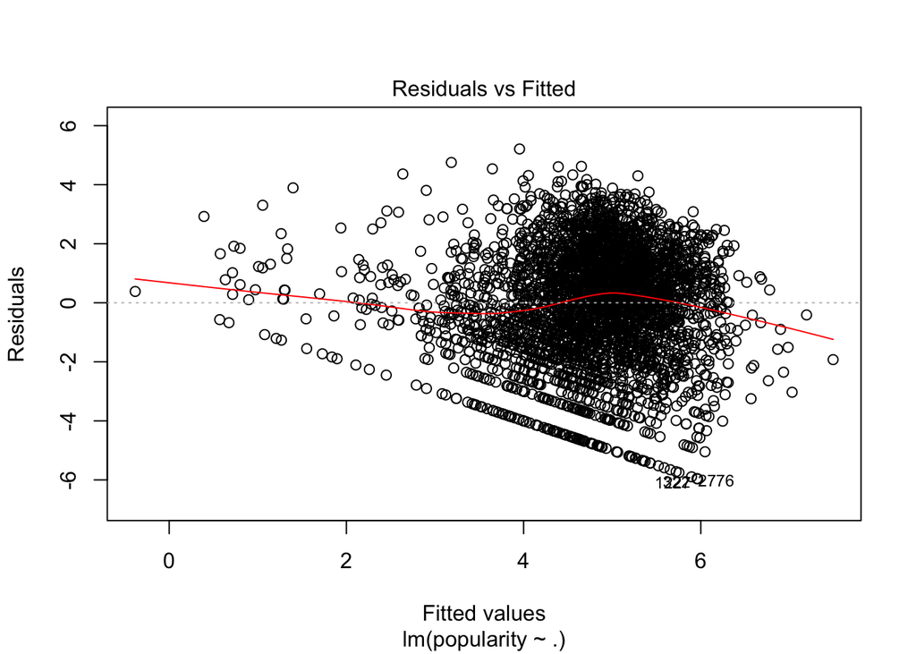

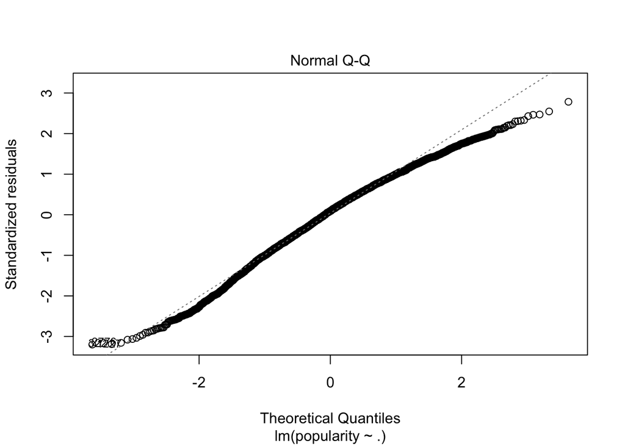

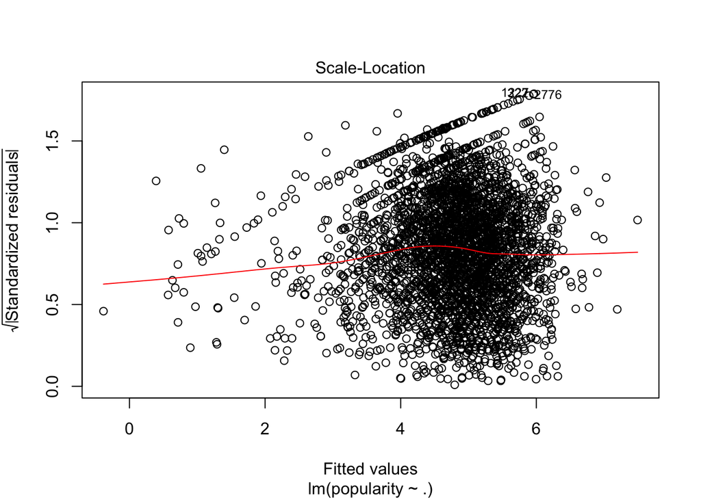

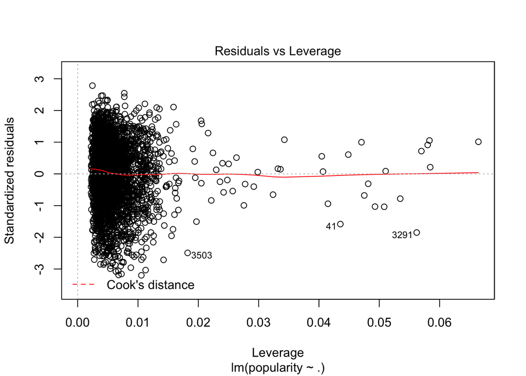

```r
plot(ml0.sqrt)
```

prediction on test data

```r
# prediction on test data
yhat.mlr = predict(ml0.sqrt, newdata = test0 %>% mutate(popularity = popularity^0.5))
# RMSE for test data
error.mlr <- yhat.mlr - test0$popularity^0.5
rmse.mlr <- sqrt(mean(error.mlr^2))
rmse.mlr
```

```
## [1] 1.863478
```